# Lab Session 5

Lidia Montero, Josep Anton Sanchez & Jordi Cortes

October 2018

## Prepare Dataset and load packages

```r
load("Eleccions_92.RData")
options(contrasts=c("contr.treatment","contr.treatment"))
library(car)
library(MASS)
library(AER)
library(effects)
library(lmtest)
library(FactoMineR)
library(rms)
library(fmsb)
library(ROCR)
library(AUC)
```

# Define response variable (pres) and factors properly.

New variables will be created: they will be use further.

```r
### Punt 1
summary(elecc92)
```

```
##        id              pres             age             educ
##  Min.   :   1.0   Min.   :0.0000   Min.   :17.00   Min.   : 0.00
##  1st Qu.: 593.2   1st Qu.:0.0000   1st Qu.:32.00   1st Qu.:12.00
##  Median :1180.5   Median :1.0000   Median :42.00   Median :12.00
##  Mean   :1193.6   Mean   :0.6956   Mean   :45.89   Mean   :12.96
##  3rd Qu.:1783.8   3rd Qu.:1.0000   3rd Qu.:59.00   3rd Qu.:15.00
##  Max.   :2485.0   Max.   :1.0000   Max.   :91.00   Max.   :17.00
##       p        arty       inter         close            sat
##  ind   :858   dem:1103   high:888   Min.   :0.000   Min.   :0.0000
##  strong:655   ind: 266   none:348   1st Qu.:1.000   1st Qu.:0.0000
##  weak  :685   rep: 829   some:962   Median :1.000   Median :0.0000
##                                     Mean   :0.818   Mean   :0.1451
##                                     3rd Qu.:1.000   3rd Qu.:0.0000
##                                     Max.   :1.000   Max.   :1.0000
```

```r
elecc92$inter<-factor(elecc92$inter,levels=c("none","some","high"))
elecc92$close<-factor(elecc92$close,labels=c("Close-No","Close-Yes"))
elecc92$sat<-factor(elecc92$sat,labels=c("Sat-No","Sat-Yes"))
elecc92$vota<-factor(elecc92$pres,labels=c("Pres-No","Pres-Yes"))
elecc92$c.age <- cut(elecc92$age,breaks=c(16,29,39,59,91))
elecc92$ones <- rep(1,length(elecc92$pres))
elecc92$c.edu <- cut(elecc92$educ,breaks=c(-1,11,12,15,17))
elecc92$p <- factor(elecc92$p,levels=c('ind','weak','strong'))

elecc92$id <- NULL # Not use

summary(elecc92)
```

```
##       pres             age             educ            p        arty
##  Min.   :0.0000   Min.   :17.00   Min.   : 0.00   ind   :858   dem:1103
##  1st Qu.:0.0000   1st Qu.:32.00   1st Qu.:12.00   weak  :685   ind: 266
##  Median :1.0000   Median :42.00   Median :12.00   strong:655   rep: 829
##  Mean   :0.6956   Mean   :45.89   Mean   :12.96
##  3rd Qu.:1.0000   3rd Qu.:59.00   3rd Qu.:15.00
##  Max.   :1.0000   Max.   :91.00   Max.   :17.00
##   inter           close           sat             vota          c.age
##  none:348   Close-No : 400   Sat-No :1879   Pres-No : 669   (16,29]:414
##  some:962   Close-Yes:1798   Sat-Yes: 319   Pres-Yes:1529   (29,39]:573
##  high:888                                                   (39,59]:664
##                                                             (59,91]:547
##
##
##       ones       c.edu
##  Min.   :1   (-1,11]:386
##  1st Qu.:1   (11,12]:735
##  Median :1   (12,15]:550
##  Mean   :1   (15,17]:527
##  3rd Qu.:1
##  Max.   :1
```

# Point 1: Exploratory Data Analysis

Categories are reasonably well balanced

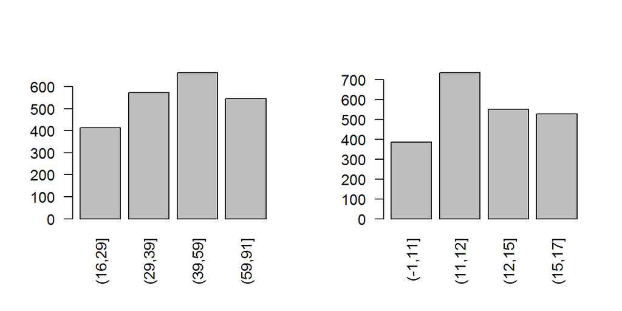

```r
par(mfrow=c(1,2),las=2)
barplot(table(elecc92$c.age))
barplot(table(elecc92$c.edu))
```

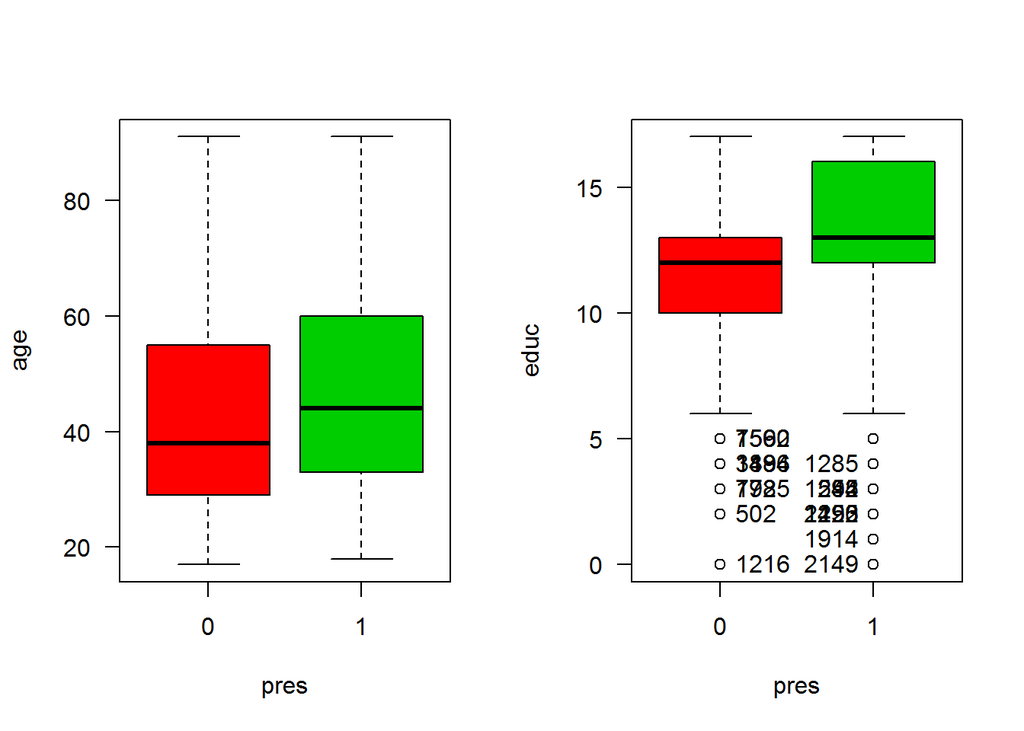

```
##  [1] "1216" "502"  "772"  "1985" "319"  "1494" "1886" "756"  "1562" "1590"
## [11] "2149" "1914" "292"  "1253" "1425" "2150" "255"  "544"  "1292" "1285"
```

```r
par(mfrow=c(1,2),las=1)
Boxplot(age~pres,data=elecc92,col=c(2,3))
Boxplot(educ~pres,data=elecc92,col=c(2,3))
```

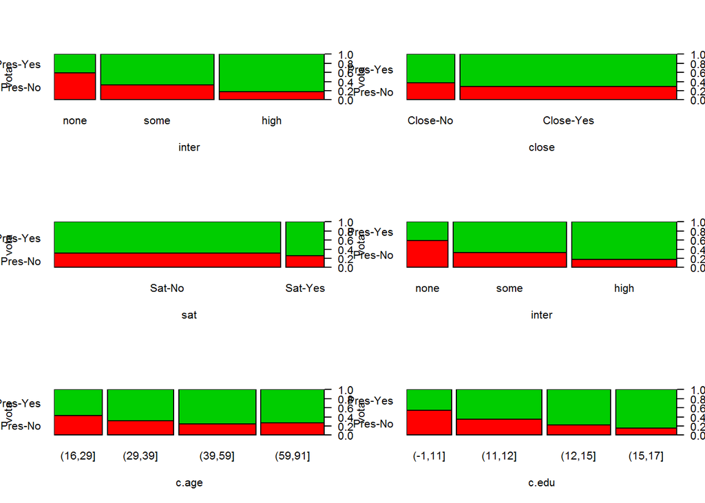

```r
par(mfrow=c(3,2),las=1)
plot(vota~inter,data=elecc92,col=c(2,3))
plot(vota~close,data=elecc92,col=c(2,3))
plot(vota~sat,data=elecc92,col=c(2,3))
plot(vota~inter,data=elecc92,col=c(2,3))
plot(vota~c.age,data=elecc92,col=c(2,3))
plot(vota~c.edu,data=elecc92,col=c(2,3))
```

# Feature Selection

```r
summary(elecc92)
```

```
##       pres             age             educ            p        arty
##  Min.   :0.0000   Min.   :17.00   Min.   : 0.00   ind   :858   dem:1103
##  1st Qu.:0.0000   1st Qu.:32.00   1st Qu.:12.00   weak  :685   ind: 266
##  Median :1.0000   Median :42.00   Median :12.00   strong:655   rep: 829
##  Mean   :0.6956   Mean   :45.89   Mean   :12.96
##  3rd Qu.:1.0000   3rd Qu.:59.00   3rd Qu.:15.00
##  Max.   :1.0000   Max.   :91.00   Max.   :17.00
##   inter           close           sat             vota          c.age
##  none:348   Close-No : 400   Sat-No :1879   Pres-No : 669   (16,29]:414
##  some:962   Close-Yes:1798   Sat-Yes: 319   Pres-Yes:1529   (29,39]:573
##  high:888                                                   (39,59]:664
##                                                             (59,91]:547
##
##
##       ones       c.edu
##  Min.   :1   (-1,11]:386
##  1st Qu.:1   (11,12]:735
##  Median :1   (12,15]:550
##  Mean   :1   (15,17]:527
##  3rd Qu.:1
##  Max.   :1
```

```r
catdes(elecc92,9)  # 9 is the index of variable vota
```

```
##
## Link between the cluster variable and the categorical variables (chi-square test)
## =================================================================================
##            p.value df
## inter 9.683893e-45  2
## c.edu 1.209523e-39  3
## arty  4.551196e-11  2
## c.age 4.327803e-10  3
## p     1.746567e-09  2
## close 2.413537e-03  1
## sat   4.699779e-02  1
##
## Description of each cluster by the categories
## =============================================
## $`Pres-No`
##                  Cla/Mod  Mod/Cla   Global      p.value     v.test
## inter=none      58.62069 30.49327 15.83258 6.241266e-33  11.953280
## c.edu=(-1,11]   54.40415 31.39013 17.56142 1.701981e-27  10.864476
## arty=ind        48.12030 19.13303 12.10191 1.071248e-10   6.456539
## c.age=(16,29]   43.23671 26.75635 18.83530 8.659355e-10   6.132344
## p=ind           36.82984 47.23468 39.03549 2.206953e-07   5.181004
## close=Close-No  36.75000 21.97309 18.19836 2.759873e-03   2.993290
## c.edu=(11,12]   34.55782 37.96712 33.43949 3.095186e-03   2.958123
## sat=Sat-No      31.24002 87.74290 85.48681 4.530385e-02   2.001822
## sat=Sat-Yes     25.70533 12.25710 14.51319 4.530385e-02  -2.001822
## c.age=(59,91]   26.32541 21.52466 24.88626 1.525128e-02  -2.426357
## close=Close-Yes 29.03226 78.02691 81.80164 2.759873e-03  -2.993290
## arty=rep        25.93486 32.13752 37.71611 3.347507e-04  -3.586808
## c.age=(39,59]   24.84940 24.66368 30.20928 1.566336e-04  -3.780309
## c.edu=(12,15]   22.72727 18.68460 25.02275 3.948670e-06  -4.614066
## p=strong        21.67939 21.22571 29.79982 3.260595e-09  -5.917909
## c.edu=(15,17]   15.18027 11.95815 23.97634 6.826780e-20  -9.130366
## inter=high      17.45495 23.16891 40.40036 8.917456e-29 -11.130460
##
## $`Pres-Yes`
##                  Cla/Mod   Mod/Cla   Global      p.value     v.test
## inter=high      82.54505 47.939830 40.40036 8.917456e-29  11.130460
## c.edu=(15,17]   84.81973 29.234794 23.97634 6.826780e-20   9.130366
## p=strong        78.32061 33.551341 29.79982 3.260595e-09   5.917909
## c.edu=(12,15]   77.27273 27.795945 25.02275 3.948670e-06   4.614066
```

[output cut: 28 more lines]

```
## pres -46.872167          0.00000    0.6956324       0.000000  0.4601391
##           p.value
## age  8.701333e-07
## educ 6.306506e-33
## pres 0.000000e+00
##
## $`Pres-Yes`
##         v.test Mean in category Overall mean sd in category Overall sd
## pres 46.872167          1.00000    0.6956324        0.00000  0.4601391
## educ 11.952416         13.42381   12.9581438        2.64555  2.7607140
## age   4.918942         47.10530   45.8930846       17.03419 17.4627626
##           p.value
## pres 0.000000e+00
## educ 6.306506e-33
## age  8.701333e-07
```

# Point 2: Aggregated vs Desaggregated data for binary response models

Disaggregated data

```r
m1 <- glm(pres~age,data=elecc92,family=binomial)
summary(m1)
```

```
##
## Call:
## glm(formula = pres ~ age, family = binomial, data = elecc92)
##
## Deviance Residuals:
##     Min       1Q   Median       3Q      Max
## -1.8208  -1.4267   0.7912   0.8915   0.9888
##
## Coefficients:
##             Estimate Std. Error z value Pr(>|z|)
## (Intercept) 0.218505   0.130528   1.674   0.0941 .
## age         0.013491   0.002756   4.895 9.81e-07 ***
## ---
## Signif. codes:  0 '***' 0.001 '**' 0.01 '*' 0.05 '.' 0.1 ' ' 1
##
## (Dispersion parameter for binomial family taken to be 1)
##
##     Null deviance: 2701.4  on 2197  degrees of freedom
## Residual deviance: 2676.7  on 2196  degrees of freedom
## AIC: 2680.7
##
## Number of Fisher Scoring iterations: 4
```

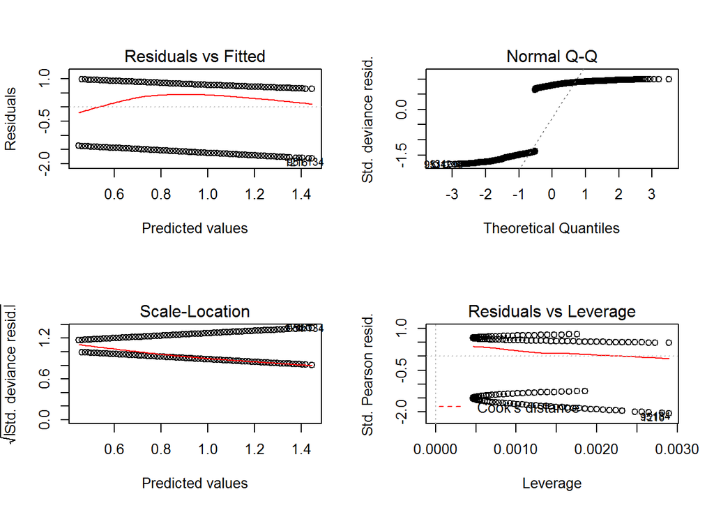

```r
par(mfrow=c(2,2))
plot(m1)
```

# Aggregated data

In this case, it is possible to aggregate by a continous variable because it is discretized and the sample size is big enough

```r
dfage <-agregacio(elecc92,1,as.formula(ones~age),as.formula(pres~age))
summary(dfage)
```

```
##       age           m              ypos            yneg
##  17     : 1   Min.   : 1.00   Min.   : 0.00   Min.   : 0.00
##  18     : 1   1st Qu.:17.50   1st Qu.:13.00   1st Qu.: 4.00
##  19     : 1   Median :29.00   Median :20.00   Median : 7.00
##  20     : 1   Mean   :29.31   Mean   :20.39   Mean   : 8.92
##  21     : 1   3rd Qu.:39.00   3rd Qu.:27.00   3rd Qu.:14.00
##  22     : 1   Max.   :65.00   Max.   :49.00   Max.   :22.00
##  (Other):69
```

```r
dfage$age<-as.numeric(levels(dfage$age))[dfage$age]
head(dfage)
```

```
##   age  m ypos yneg
## 1  17  1    0    1
## 2  18 10    8    2
## 3  19 16    7    9
## 4  20 33   16   17
## 5  21 29   15   14
## 6  22 30   14   16
```

```r
summary(dfage)
```

```
##       age             m              ypos            yneg
##  Min.   :17.0   Min.   : 1.00   Min.   : 0.00   Min.   : 0.00
##  1st Qu.:35.5   1st Qu.:17.50   1st Qu.:13.00   1st Qu.: 4.00
##  Median :54.0   Median :29.00   Median :20.00   Median : 7.00
##  Mean   :54.0   Mean   :29.31   Mean   :20.39   Mean   : 8.92
##  3rd Qu.:72.5   3rd Qu.:39.00   3rd Qu.:27.00   3rd Qu.:14.00
##  Max.   :91.0   Max.   :65.00   Max.   :49.00   Max.   :22.00
```

In the model, the coefficients are the same that those ones with dissagragated data, but not the deviance and degrees of freedom.

```r
m1a <- glm(cbind(ypos,yneg)~age,data=dfage,family=binomial)
summary(m1a)
```

```
##
## Call:
## glm(formula = cbind(ypos, yneg) ~ age, family = binomial, data = dfage)
##
## Deviance Residuals:
##      Min        1Q    Median        3Q       Max
## -3.15560  -0.85674  -0.04032   0.67715   2.32055
##
## Coefficients:
##             Estimate Std. Error z value Pr(>|z|)
## (Intercept) 0.218505   0.130528   1.674   0.0941 .
## age         0.013491   0.002756   4.895 9.81e-07 ***
## ---
## Signif. codes:  0 '***' 0.001 '**' 0.01 '*' 0.05 '.' 0.1 ' ' 1
##
## (Dispersion parameter for binomial family taken to be 1)
##
##     Null deviance: 123.992  on 74  degrees of freedom
## Residual deviance:  99.299  on 73  degrees of freedom
## AIC: 349.2
##
## Number of Fisher Scoring iterations: 4
```

# Goodness of fit

When disaggregated data is used then $m_i = 1$ and asymptotic theory does not apply, as a rule of thumb at a fully disaggregated level for data, a model is good if Deviance or Pearson $\chi^2$ statistics are similar to degrees of freedom of the model. Large values indicate a lack of fit of the model.

```r
1-pchisq(m1a$dev,m1a$df.res)  # Aggregated data model
```

```
## [1] 0.02206015
```

```r
m1$dev;m1$df.res              # Disaggregated data
```

```
## [1] 2676.735
```

```
## [1] 2196
```

# Interpretation

The exponential of the coefficient represents the OR on the positive response for a 1-year increase.

```r
# Interpretacio efecte age en m1
exp(coef(m1)['age'])      # Increment 1 any respecte any anterior
```

```
##      age
## 1.013583
```

```r
exp(10*coef(m1)['age'])   # Increment 10 anys respecte any partida
```

```
##      age
## 1.144438
```

Let’s check the fit using a manual plot and also residual analysis methods available in package car

By hand:

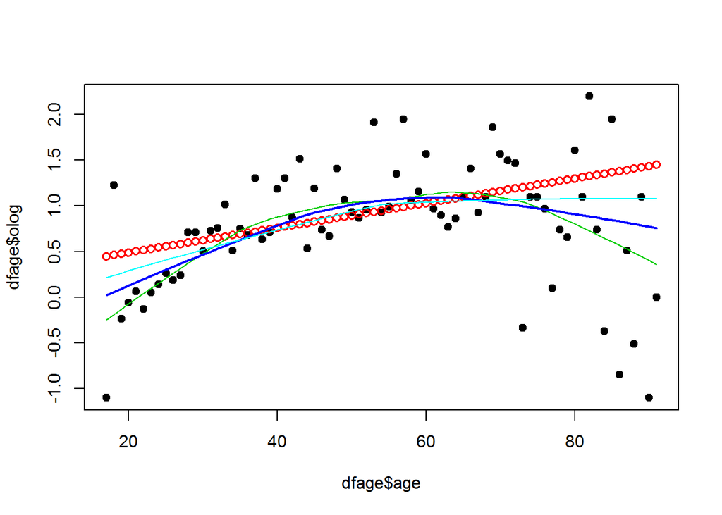

```r
par(mfrow=c(1,1))
dfage$olog <- log((dfage$ypos+0.5)/(dfage$yneg+0.5))    # logodds
plot(dfage$age,dfage$olog,pch=19)                       # points
points(dfage$age,m1a$linear.predictor,col=2,lwd=1.5)    # Linear relationship
lines(lowess(dfage$age,dfage$olog,f=0.5),col=3)         # high smooth
lines(lowess(dfage$age,dfage$olog,f=0.75),col=4,lwd=2)  # medium smooth
lines(lowess(dfage$age,dfage$olog,f=1.0),col=5)         # low smooth
```

Package car:

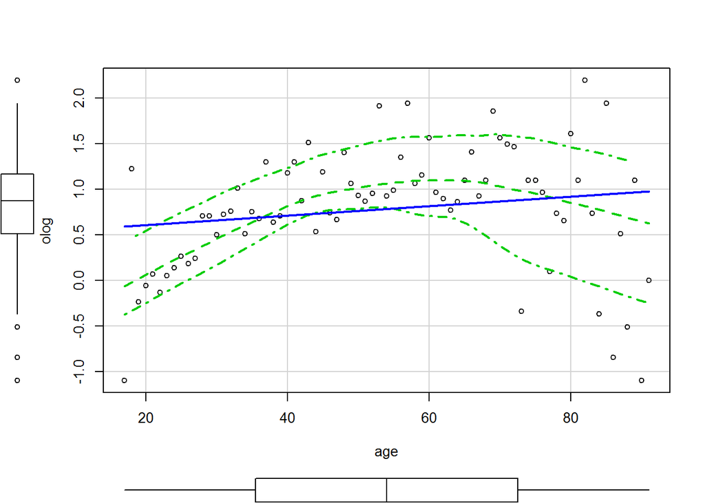

```r
scatterplot(olog~age,dfage,col=1,regLine=list(col=4),smooth=list(col.smooth=3,col.var=3))
```

Effects

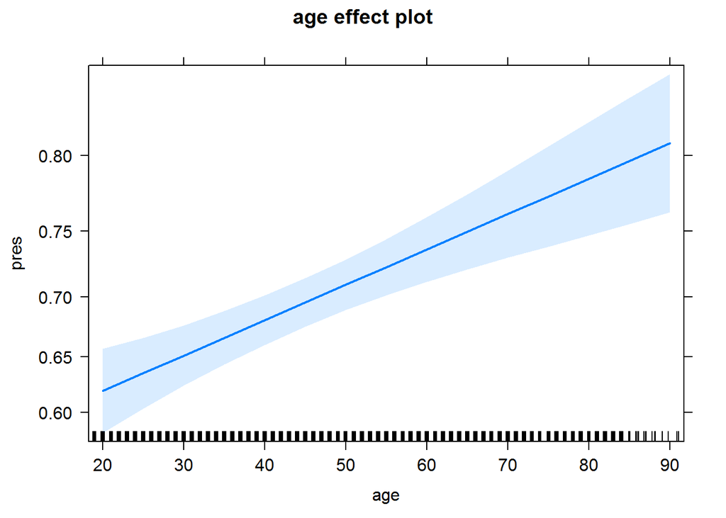

```r
plot(allEffects(m1),ask=FALSE)
```

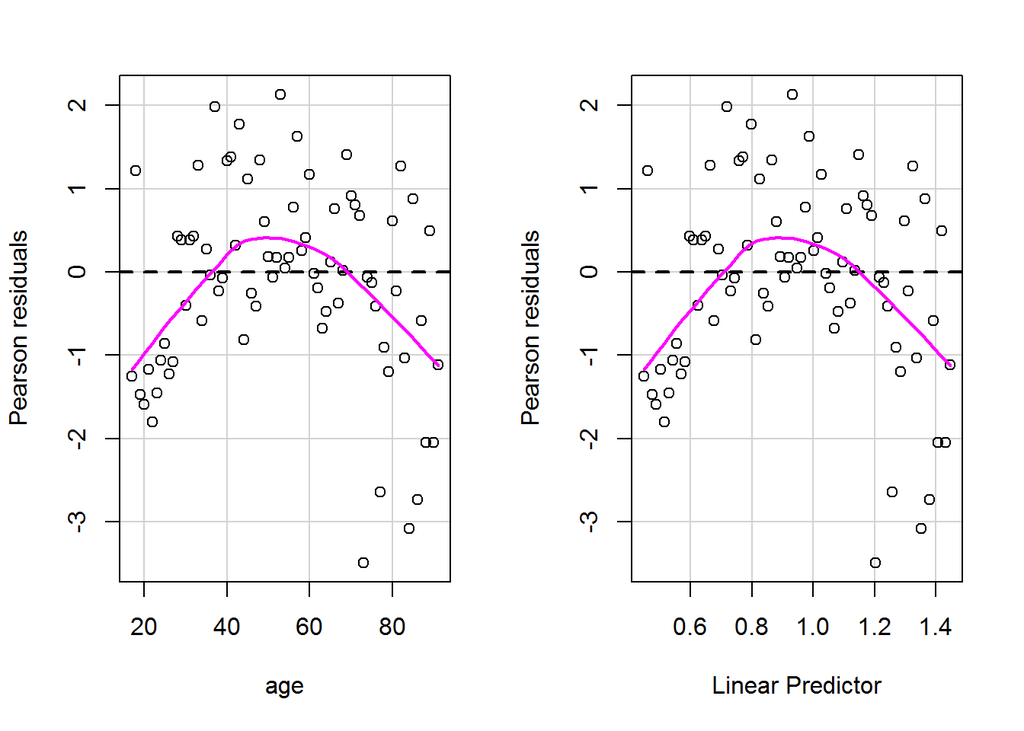

```
##     Test stat Pr(>|Test stat|)
## age    30.127        4.047e-08 ***
## ---
## Signif. codes:  0 '***' 0.001 '**' 0.01 '*' 0.05 '.' 0.1 ' ' 1
```

```r
residualPlots(m1a, layout=c(1, 2))
```

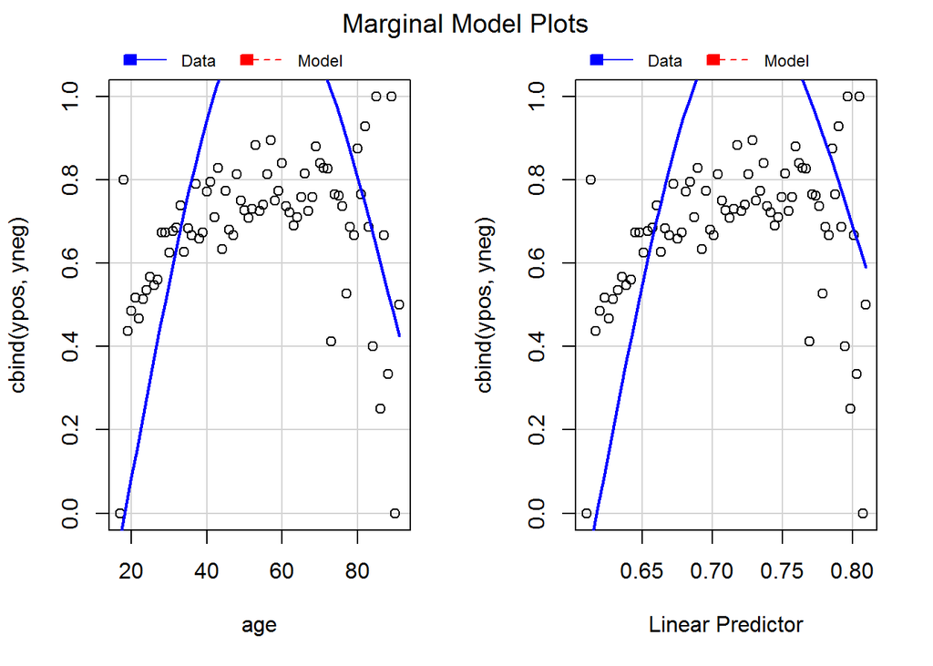

```r
marginalModelPlots(m1a,id=list(method=abs(cooks.distance(m1)),n=5))
```

# Point 3: Exercicis

3. Ajusteu un model de regressió logística amb predictor lineal els termes d’ordre 1 i 2 de l’EDAT (Models M1-2, M1-3, variants de M1) (els ordres no lineals obteniu-los sempre respecte la tendència central de la variable o empreu la comanda poly(EDAT,k)).

Dos metodes: amb la funcio $I$ o amb la funcio $poly$. Es centra per a que tingui sentit el valor nul.

```r
m1.1 <-  glm(pres ~ age, data=elecc92,family=binomial)
m1.2 <-  glm(pres ~ age + I((age-42)^2), data=elecc92,family=binomial)
m1.3 <-  glm(pres ~ age + I((age-42)^2) + I((age-42)^3), data=elecc92,family=binomial)
m1.2p <- glm(pres ~ poly(age,2,raw=TRUE),data=elecc92,family=binomial)
m1.3p <- glm(pres ~ poly(age,3),data=elecc92,family=binomial)
```

1. Contrasteu formalment la significació del terme d’ordre 3 de l’edat: segons l’estadístic de Wald i segons el contrast de la deviança.

```r
anova(m1.2,m1.3,test="Chisq")              # Deviance
```

```
## Analysis of Deviance Table
##
## Model 1: pres ~ age + I((age - 42)^2)
## Model 2: pres ~ age + I((age - 42)^2) + I((age - 42)^3)
##   Resid. Df Resid. Dev Df Deviance Pr(>Chi)
## 1      2195     2646.6
## 2      2194     2646.6  1  0.02304   0.8794
```

```r
anova(m1.2p,m1.3p,test="Chisq")            # Deviance --> Equivalent to previous
```

```
## Analysis of Deviance Table
##
## Model 1: pres ~ poly(age, 2, raw = TRUE)
## Model 2: pres ~ poly(age, 3)
##   Resid. Df Resid. Dev Df Deviance Pr(>Chi)
## 1      2195     2646.6
## 2      2194     2646.6  1  0.02304   0.8794
```

```r
waldtest(m1.2,m1.3,test="Chisq")           # Wald
```

```
## Wald test
##
## Model 1: pres ~ age + I((age - 42)^2)
## Model 2: pres ~ age + I((age - 42)^2) + I((age - 42)^3)
##   Res.Df Df Chisq Pr(>Chisq)
## 1   2195
## 2   2194  1 0.023     0.8793
```

```r
linearHypothesis(m1.3p,"poly(age, 3)3=0")  # Wald --> Equivalent to previous
```

```
## Linear hypothesis test
##
## Hypothesis:
## poly(age, 3)3 = 0
##
## Model 1: restricted model
## Model 2: pres ~ poly(age, 3)
##
##   Res.Df Df Chisq Pr(>Chisq)
## 1   2195
## 2   2194  1 0.023     0.8793
```

2. Contrasteu formalment la significació del terme d’ordre 2 de l’edat: segons l’estadístic de Wald i segons el contrast de la deviança.

```r
anova(m1,m1.2,test="Chisq")      # Deviance
```

```
## Analysis of Deviance Table
##
## Model 1: pres ~ age
## Model 2: pres ~ age + I((age - 42)^2)
##   Resid. Df Resid. Dev Df Deviance  Pr(>Chi)
## 1      2196     2676.7
## 2      2195     2646.6  1   30.127 4.047e-08 ***
## ---
## Signif. codes:  0 '***' 0.001 '**' 0.01 '*' 0.05 '.' 0.1 ' ' 1
```

```r
waldtest(m1,m1.2,test="Chisq")   # Wald
```

```
## Wald test
##
## Model 1: pres ~ age
## Model 2: pres ~ age + I((age - 42)^2)
##   Res.Df Df  Chisq Pr(>Chisq)
## 1   2196
## 2   2195  1 30.642  3.103e-08 ***
## ---
## Signif. codes:  0 '***' 0.001 '**' 0.01 '*' 0.05 '.' 0.1 ' ' 1
```

3. Useu sobre el conjunt de dades desagregat la comanda: marginalModelPlots() en m1 i model triat.

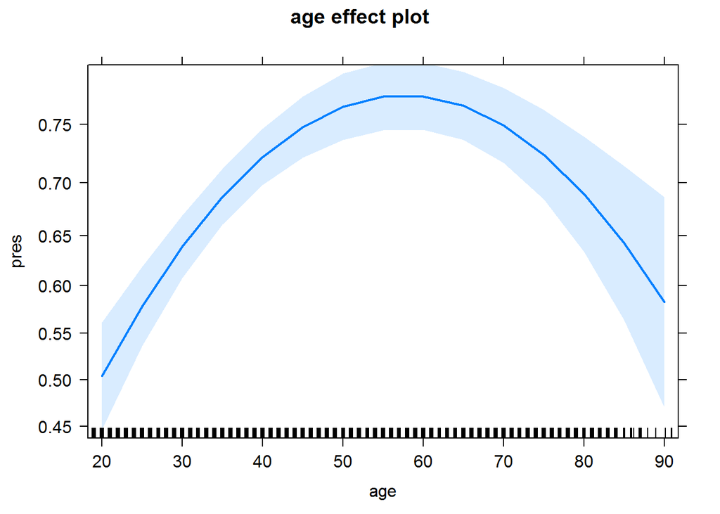

```r
plot(allEffects(m1.2p),ask=FALSE)
```

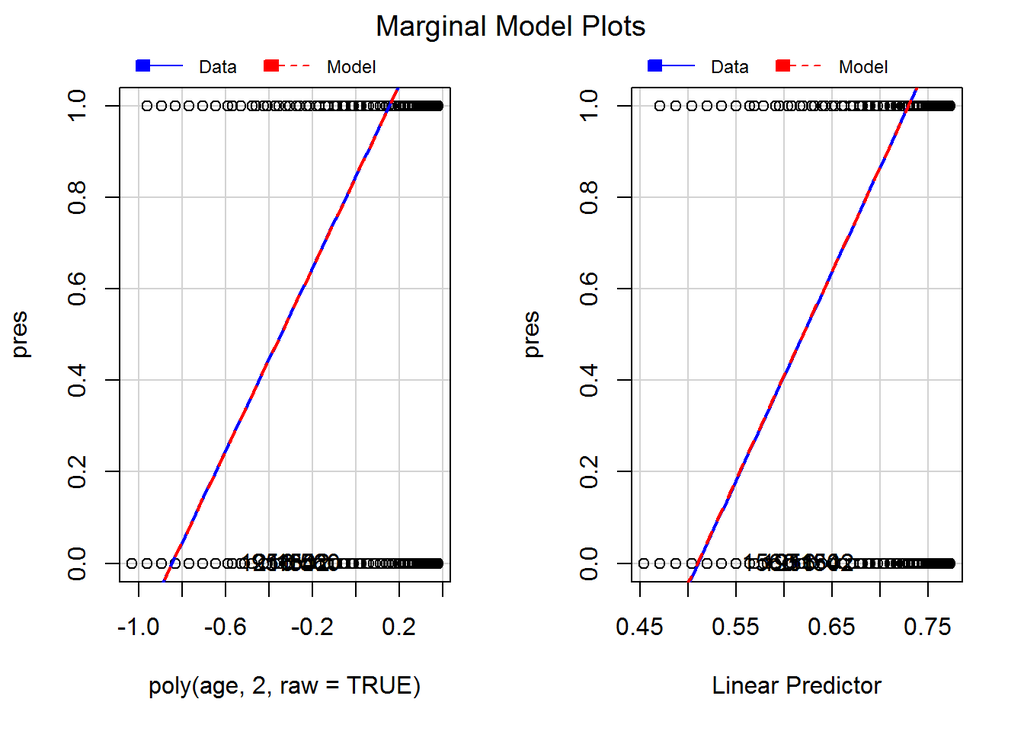

```r
par(mfrow=c(2,2))
marginalModelPlots(m1.2p,id=list(method=abs(cooks.distance(m1.2p)),n=5))
```

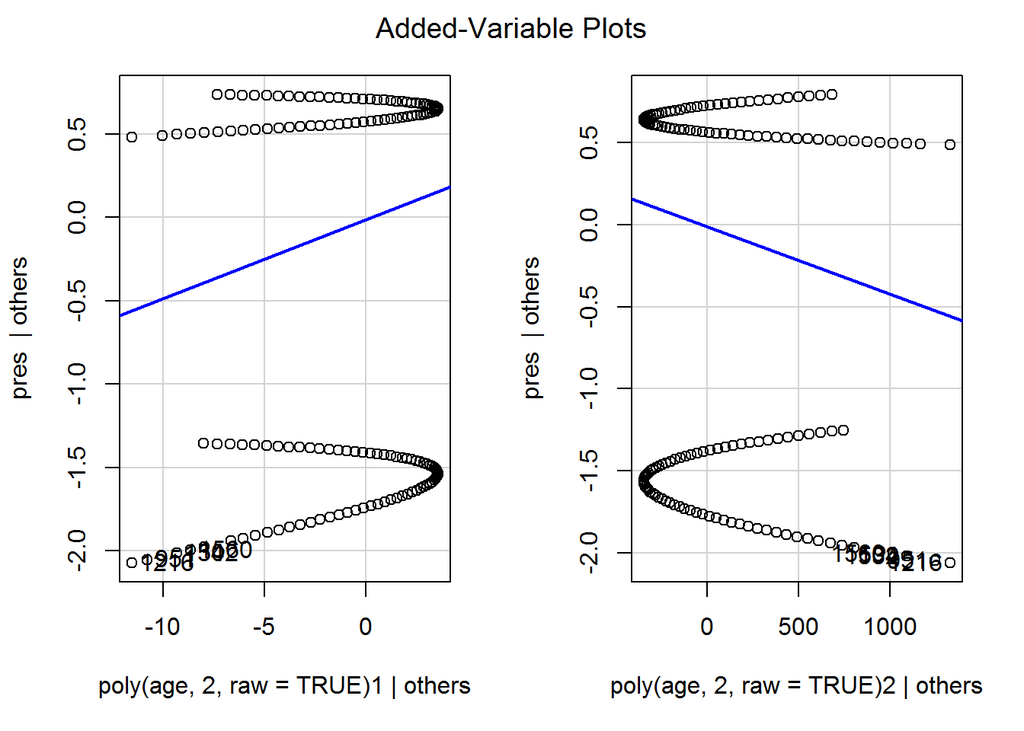

```r
avPlots(m1.2p,id=list(method=abs(cooks.distance(m1.2p)),n=5))
```

```r
summary(m1.2p)
```

```
##
## Call:
## glm(formula = pres ~ poly(age, 2, raw = TRUE), family = binomial,
##     data = elecc92)
##
## Deviance Residuals:
##     Min       1Q   Median       3Q      Max
## -1.7218  -1.3383   0.7471   0.8525   1.2269
##
## Coefficients:
##                             Estimate Std. Error z value Pr(>|z|)
## (Intercept)               -1.6086953  0.3558572  -4.521 6.17e-06 ***
## poly(age, 2, raw = TRUE)1  0.0982885  0.0156448   6.282 3.33e-10 ***
## poly(age, 2, raw = TRUE)2 -0.0008524  0.0001540  -5.536 3.10e-08 ***
## ---
## Signif. codes:  0 '***' 0.001 '**' 0.01 '*' 0.05 '.' 0.1 ' ' 1
##
## (Dispersion parameter for binomial family taken to be 1)
##
##     Null deviance: 2701.4  on 2197  degrees of freedom
## Residual deviance: 2646.6  on 2195  degrees of freedom
## AIC: 2652.6
##
## Number of Fisher Scoring iterations: 4
```

4. Feu una diagnosi estàndard del model desagregat triat (m1): residualPlots()

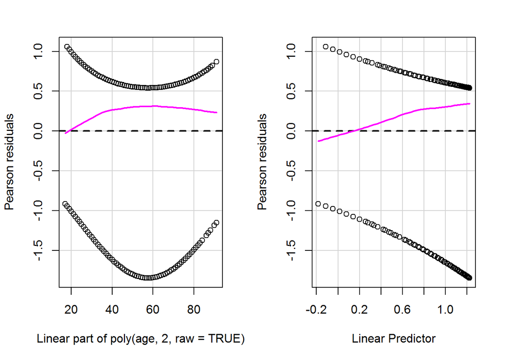

```r
residualPlots(m1.2p, layout=c(1, 2))
```

4. Considereu l’agrupació de l’EDAT en categories <30, 30-39, 40-59, 60+. Diem-li Model (M2). Tornarem a calcular el model m2 amb dades desagregades (i si en teniu ganes m2a amb dades agregades).
1. Feu una diagnosi estàndard del model desagregat (m2c): residualPlots(m2c)
2. Representeu el logits empírics/ajustats en funció de l’EDAT Categoritzada en les dades agregades (diagnosi artesanal). Pistes: Us ho podeu estalviar examinant atentament el sumari del model agregat m2a.

```r
m1c <- glm(pres~c.age,data=elecc92,family=binomial)
summary(m1c)
```

```
##
## Call:
## glm(formula = pres ~ c.age, family = binomial, data = elecc92)
##
## Deviance Residuals:
##     Min       1Q   Median       3Q      Max
## -1.6687  -1.2950   0.7559   0.8713   1.0642
##
## Coefficients:
##              Estimate Std. Error z value Pr(>|z|)
## (Intercept)   0.27220    0.09921   2.744 0.006074 **
## c.age(29,39]  0.50057    0.13386   3.740 0.000184 ***
## c.age(39,59]  0.83446    0.13382   6.236 4.49e-10 ***
## c.age(59,91]  0.75692    0.13881   5.453 4.95e-08 ***
## ---
## Signif. codes:  0 '***' 0.001 '**' 0.01 '*' 0.05 '.' 0.1 ' ' 1
##
## (Dispersion parameter for binomial family taken to be 1)
##
##     Null deviance: 2701.4  on 2197  degrees of freedom
## Residual deviance: 2656.3  on 2194  degrees of freedom
## AIC: 2664.3
##
## Number of Fisher Scoring iterations: 4
```

```r
exp(coef(m1c)['c.age(39,59]'])          # OR for this category in respect to reference
```

```
## c.age(39,59]
##     2.303572
```

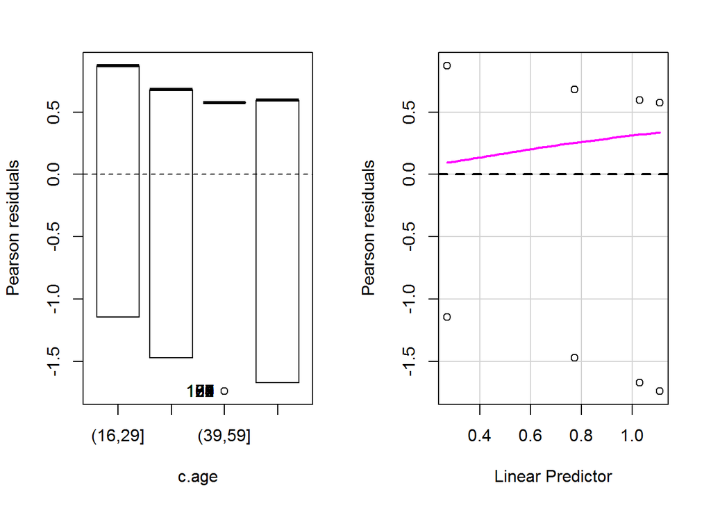

```r
residualPlots(m1c , layout=c(1, 2))
```

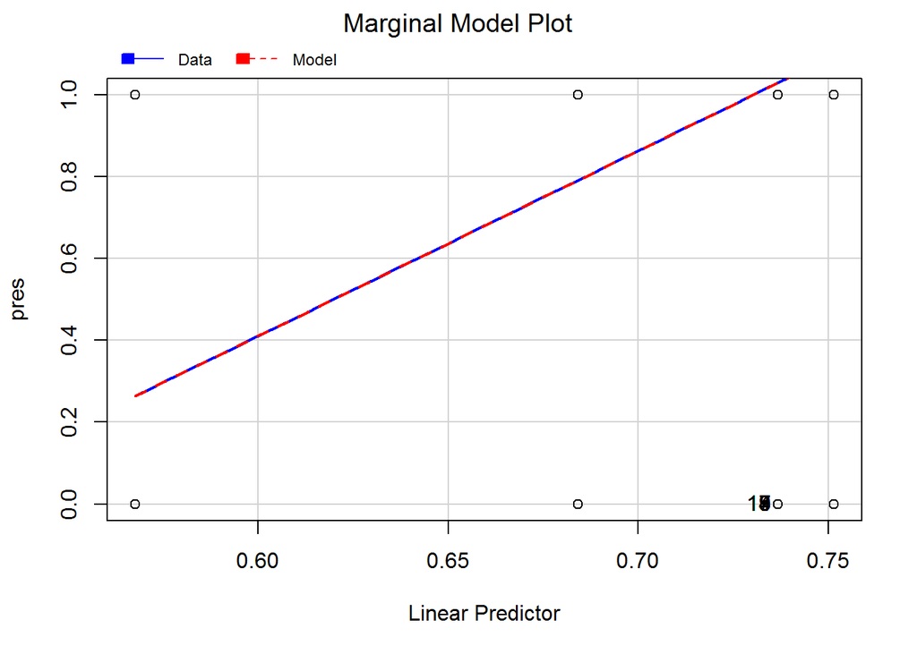

```r
marginalModelPlots(m1c,id=list(method=abs(cooks.distance(m1c)),n=5))
```

5. Quin tractament us sembla més adient per la variable EDAT: com a covariable (fins a quin terme d’ordre) o com a factor. Justifiqueu estadísticament la resposta.

No són niuats el model, per tant no podem usar la deviança.

```r
AIC(m1,m1.2p,m1c)
```

```
##       df      AIC
## m1     2 2680.735
## m1.2p  3 2652.608
## m1c    4 2664.311
```

```r
BIC(m1,m1.2p,m1c)
```

```
##       df      BIC
## m1     2 2692.126
## m1.2p  3 2669.694
## m1c    4 2687.092
```

6. Ara estudiarem la introducció de la variable EDUCACIÓ en el model que ja conté l’EDAT (en el seu millor tractament). Per començar es treballarà amb l’EDUCACIÓ com a covariant.
1. Afegiu un terme lineal d’EDUCACIÓ en el millor model anterior amb l’EDAT.

```r
m3n.1  <- glm(pres ~ poly(age,2) + educ,data=elecc92,family=binomial)
summary(m3n.1)
```

```
##
## Call:
## glm(formula = pres ~ poly(age, 2) + educ, family = binomial,
##     data = elecc92)
##
## Deviance Residuals:
##     Min       1Q   Median       3Q      Max
## -2.2925  -1.1419   0.6270   0.8418   2.0017
##
## Coefficients:
##               Estimate Std. Error z value Pr(>|z|)
## (Intercept)   -2.34963    0.25587  -9.183  < 2e-16 ***
## poly(age, 2)1 20.64414    2.46252   8.383  < 2e-16 ***
## poly(age, 2)2 -6.43438    2.31345  -2.781  0.00541 **
## educ           0.25289    0.02029  12.465  < 2e-16 ***
## ---
## Signif. codes:  0 '***' 0.001 '**' 0.01 '*' 0.05 '.' 0.1 ' ' 1
##
## (Dispersion parameter for binomial family taken to be 1)
##
##     Null deviance: 2701.4  on 2197  degrees of freedom
## Residual deviance: 2469.9  on 2194  degrees of freedom
## AIC: 2477.9
##
## Number of Fisher Scoring iterations: 4
```

2. Interpreteu el coeficient estimat en termes dels logodds, odds i probabilitats.

```r
b_edu <- coef(m3n.1)['educ']  # Increment en logodd
exp(coef(m3n.1)['educ'])      # Increment en odds --> OR
```

```
##     educ
## 1.287742
```

3. Contrasteu la hipòtesi que l’efecte de EDUCACIÓ és lineal mitjançant la introducció d’un terme d’ordre 2 en el model. I el terme d’ordre 3, és significatiu? Pareu a l’ordre 3.

```r
m3n.2  <- glm(pres ~ poly(age,2) + poly(educ,2),data=elecc92,family=binomial)
m3n.3  <- glm(pres ~ poly(age,2) + poly(educ,3),data=elecc92,family=binomial)

anova(m3n.1,m3n.2,test="Chisq")
```

```
## Analysis of Deviance Table
##
## Model 1: pres ~ poly(age, 2) + educ
## Model 2: pres ~ poly(age, 2) + poly(educ, 2)
##   Resid. Df Resid. Dev Df Deviance Pr(>Chi)
## 1      2194     2469.9
## 2      2193     2463.1  1   6.8348  0.00894 **
## ---
## Signif. codes:  0 '***' 0.001 '**' 0.01 '*' 0.05 '.' 0.1 ' ' 1
```

```r
anova(m3n.2,m3n.3,test="Chisq")
```

```
## Analysis of Deviance Table
##
## Model 1: pres ~ poly(age, 2) + poly(educ, 2)
## Model 2: pres ~ poly(age, 2) + poly(educ, 3)
##   Resid. Df Resid. Dev Df Deviance Pr(>Chi)
## 1      2193     2463.1
## 2      2192     2439.2  1   23.853 1.04e-06 ***
## ---
## Signif. codes:  0 '***' 0.001 '**' 0.01 '*' 0.05 '.' 0.1 ' ' 1
```

4. Trieu el millor model que empra l’EDAT i la covariant EDUCACIÓ: li direm (m3n). No cal treballar amb la versió agregada tret que vulgueu fer diagnosi artesanal.

```r
m3n <- m3n.3
```

5. Useu les eines standard d’anàlisi de residus: marginalModelPlots() i residualPlots().

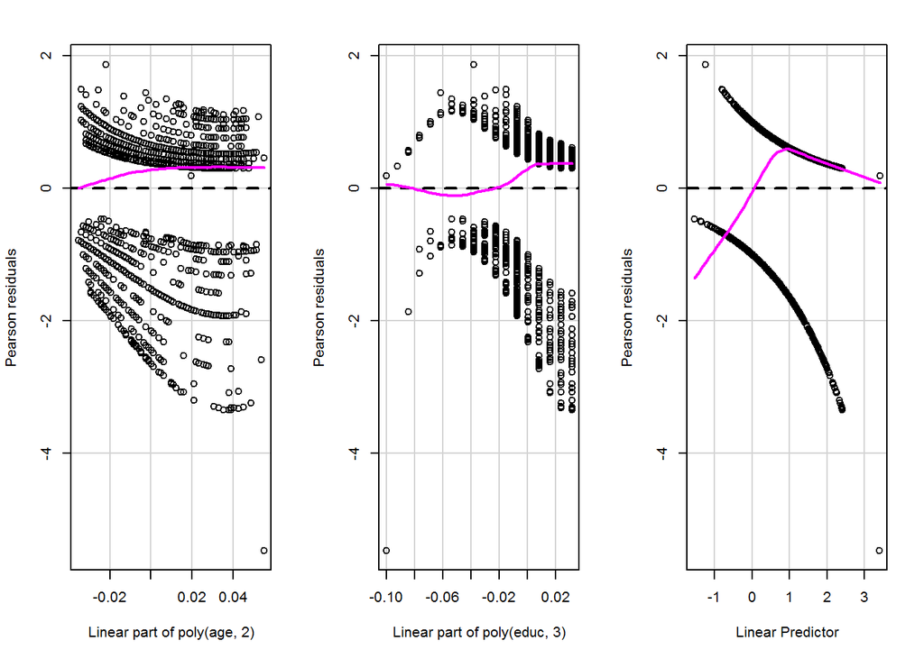

```r
residualPlots(m3n , layout=c(1, 3))
```

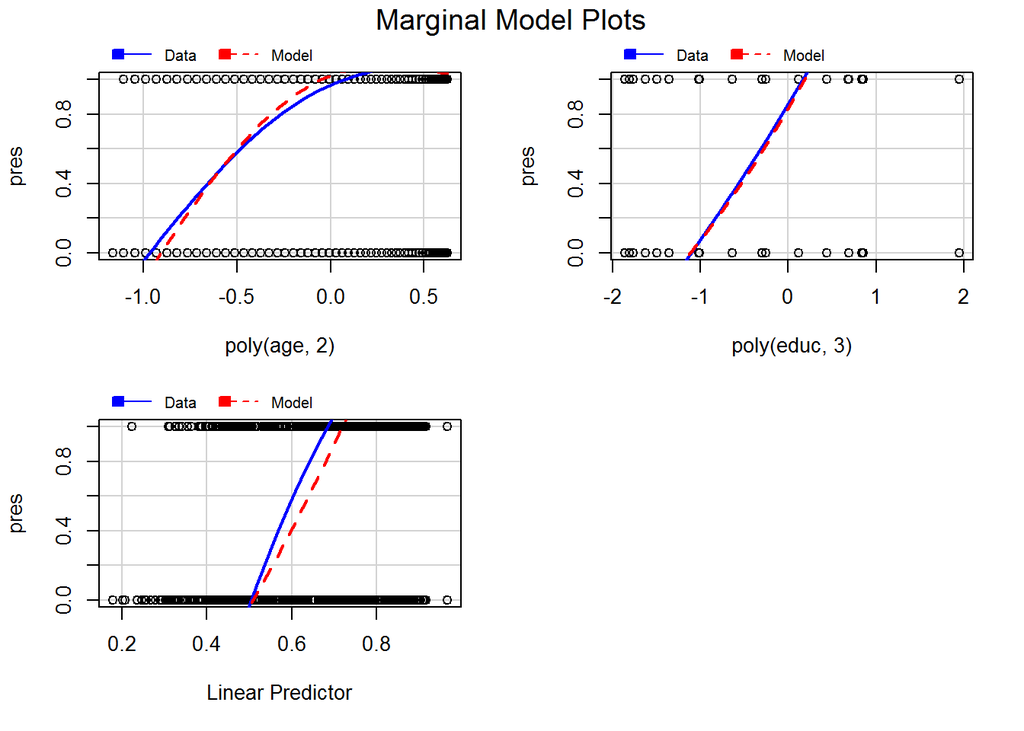

```r
marginalModelPlots(m3n,labels=row.names(elecc92),id.method=abs(cooks.distance(m3n)), id.n=5)
```

7. Considereu una agrupació dels anys d’educació (EDUCACIÓ Categoritzada) en 4 grups: <12, 12, 13-15, 16+. Estimeu el model de regressió logística amb els termes i tractament adient de l’edat i el factor EDUCACIÓ. Quina és la millor manera de tractar els anys d’educació? Li direm (M4).
1. Assageu rectes amb pendents idèntics per cada categoría d’EDUCACIO
2. Assageu rectes amb pendents diferents per cada categoría d’EDUCACIO

4. Assageu paràboles amb diferent corbatura per cada categoría d’EDUCACIO
5. Estrictament per inferència, quin us sembla el tractament més apropiat.

```r
m4.1  <-glm(pres ~ age + c.edu, data=elecc92,family=binomial)
m4.2  <-glm(pres ~ age * c.edu, data=elecc92,family=binomial)
m4.3  <-glm(pres ~ poly(age,2) + c.edu,data=elecc92,family=binomial)
m4.4  <-glm(pres ~ poly(age,2) * c.edu,data=elecc92,family=binomial)


anova(m4.1,m4.2,test="Chisq")
```

```
## Analysis of Deviance Table
##
## Model 1: pres ~ age + c.edu
## Model 2: pres ~ age * c.edu
##   Resid. Df Resid. Dev Df Deviance  Pr(>Chi)
## 1      2193     2434.5
## 2      2190     2413.0  3   21.474 8.393e-05 ***
## ---
## Signif. codes:  0 '***' 0.001 '**' 0.01 '*' 0.05 '.' 0.1 ' ' 1
```

```r
anova(m4.2,m4.3,test="Chisq")
```

```
## Analysis of Deviance Table
##
## Model 1: pres ~ age * c.edu
## Model 2: pres ~ poly(age, 2) + c.edu
##   Resid. Df Resid. Dev Df Deviance Pr(>Chi)
## 1      2190     2413.0
## 2      2192     2424.4 -2  -11.342 0.003445 **
## ---
## Signif. codes:  0 '***' 0.001 '**' 0.01 '*' 0.05 '.' 0.1 ' ' 1
```

```r
anova(m4.3,m4.4,test="Chisq")
```

```
## Analysis of Deviance Table
##
## Model 1: pres ~ poly(age, 2) + c.edu
## Model 2: pres ~ poly(age, 2) * c.edu
##   Resid. Df Resid. Dev Df Deviance  Pr(>Chi)
## 1      2192     2424.4
## 2      2186     2389.2  6   35.154 4.023e-06 ***
## ---
## Signif. codes:  0 '***' 0.001 '**' 0.01 '*' 0.05 '.' 0.1 ' ' 1
```

Effects

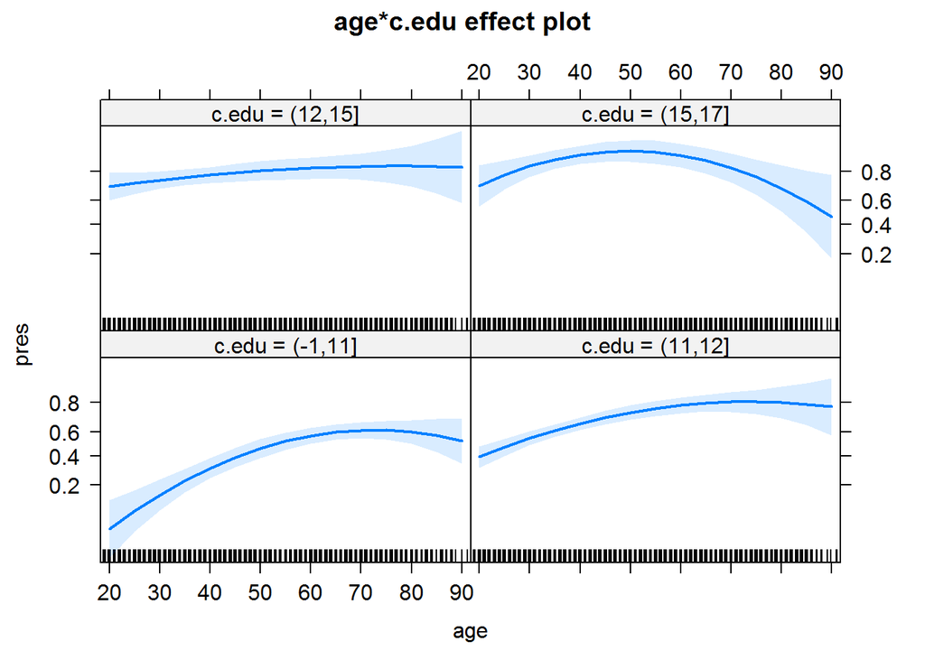

```r
plot(allEffects(m4.4),ask=FALSE)
```

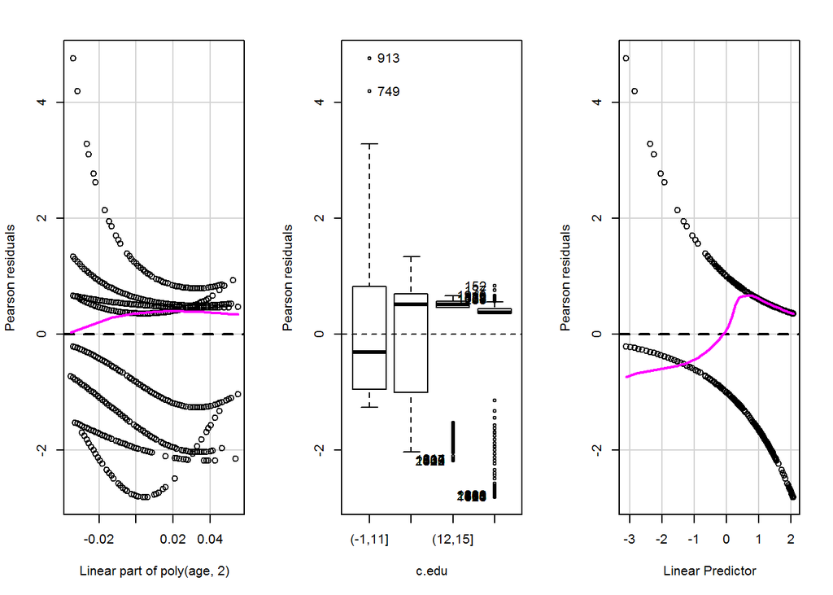

```r
residualPlots(m4.4 , layout=c(1, 3))
```

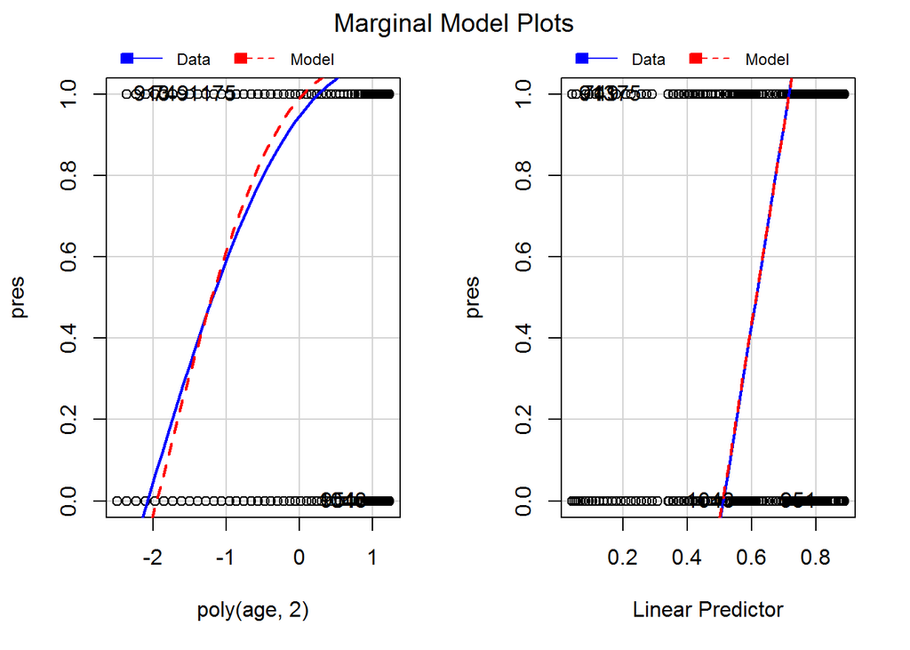

```r
marginalModelPlots(m4.4,id=list(method=abs(cooks.distance(m4.4)),n=5))
```

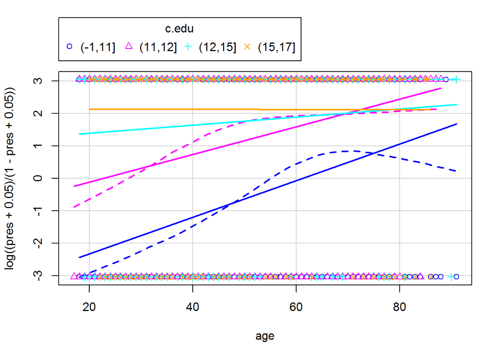

```r
scatterplot(log((pres+0.05)/(1-pres+0.05))~age|c.edu,smooth=TRUE,data=elecc92)
```

8. Quina és la millor manera de tractar els anys d’educació, un cop l’EDAT ja ha estat incorporada en el model? Comparing models by AIC and BIC

```r
BIC(m4.1,m4.2,m4.3,m4.4)
```

```
##      df      BIC
## m4.1  5 2472.970
## m4.2  8 2474.582
## m4.3  6 2470.533
## m4.4 12 2481.551
```

```r
AIC(m4.1,m4.2,m4.3,m4.4)
```

```
##      df      AIC
## m4.1  5 2444.493
## m4.2  8 2429.020
## m4.3  6 2436.362
## m4.4 12 2413.207
```

# Interpretation of two models

```r
summary(m4.3)
```

```
##
## Call:
## glm(formula = pres ~ poly(age, 2) + c.edu, family = binomial,
##     data = elecc92)
##
## Deviance Residuals:
##     Min       1Q   Median       3Q      Max
## -2.2332  -1.0747   0.5961   0.8026   1.8667
##
## Coefficients:
##               Estimate Std. Error z value Pr(>|z|)
## (Intercept)    -0.4344     0.1120  -3.880 0.000105 ***
## poly(age, 2)1  21.6103     2.5231   8.565  < 2e-16 ***
## poly(age, 2)2  -7.4216     2.3173  -3.203 0.001361 **
## c.edu(11,12]    1.1415     0.1406   8.117 4.78e-16 ***
## c.edu(12,15]    1.8314     0.1598  11.458  < 2e-16 ***
## c.edu(15,17]    2.2278     0.1723  12.930  < 2e-16 ***
## ---
## Signif. codes:  0 '***' 0.001 '**' 0.01 '*' 0.05 '.' 0.1 ' ' 1
##
## (Dispersion parameter for binomial family taken to be 1)
##
##     Null deviance: 2701.4  on 2197  degrees of freedom
## Residual deviance: 2424.4  on 2192  degrees of freedom
## AIC: 2436.4
##
## Number of Fisher Scoring iterations: 4
```

```r
summary(m4.4)
```

```
##
## Call:
## glm(formula = pres ~ poly(age, 2) * c.edu, family = binomial,
##     data = elecc92)
##
## Deviance Residuals:
##     Min       1Q   Median       3Q      Max
## -2.0898  -1.0227   0.6312   0.7636   2.5148
##
## Coefficients:
##                            Estimate Std. Error z value Pr(>|z|)
## (Intercept)                 -0.7596     0.1543  -4.924 8.48e-07 ***
## poly(age, 2)1               44.1531     6.7271   6.563 5.26e-11 ***
## poly(age, 2)2              -16.7379     5.3515  -3.128  0.00176 **
## c.edu(11,12]                 1.4829     0.1751   8.470  < 2e-16 ***
## c.edu(12,15]                 2.0426     0.1885  10.838  < 2e-16 ***
## c.edu(15,17]                 2.3976     0.1984  12.082  < 2e-16 ***
## poly(age, 2)1:c.edu(11,12] -19.3749     7.8940  -2.454  0.01411 *
## poly(age, 2)2:c.edu(11,12]   7.7314     6.6637   1.160  0.24595
## poly(age, 2)1:c.edu(12,15] -34.7626     8.6055  -4.040 5.35e-05 ***
## poly(age, 2)2:c.edu(12,15]  13.8642     7.3578   1.884  0.05953 .
## poly(age, 2)1:c.edu(15,17] -45.7933     9.2769  -4.936 7.96e-07 ***
## poly(age, 2)2:c.edu(15,17]  -2.0272     8.3764  -0.242  0.80877
## ---
## Signif. codes:  0 '***' 0.001 '**' 0.01 '*' 0.05 '.' 0.1 ' ' 1
##
## (Dispersion parameter for binomial family taken to be 1)
##
##     Null deviance: 2701.4  on 2197  degrees of freedom
## Residual deviance: 2389.2  on 2186  degrees of freedom
## AIC: 2413.2
##
## Number of Fisher Scoring iterations: 4
```

9. Afegir al model les preferències partidistes. Analitzar els coeficients estimats i suggerir com es podria recodificar aquesta variable per simplificar la interpretació del model i estalviar un quants graus de llibertat (heu de veure que amb màxim 3 categories és suficient). Reajustar el model i reinterpretar els coeficients de la variable codificada.

Crear nova variable:

```r
elecc92$party <- as.factor(paste(elecc92$p,elecc92$arty))
summary(elecc92)
```

```
##       pres             age             educ            p        arty
##  Min.   :0.0000   Min.   :17.00   Min.   : 0.00   ind   :858   dem:1103
##  1st Qu.:0.0000   1st Qu.:32.00   1st Qu.:12.00   weak  :685   ind: 266
##  Median :1.0000   Median :42.00   Median :12.00   strong:655   rep: 829
##  Mean   :0.6956   Mean   :45.89   Mean   :12.96
##  3rd Qu.:1.0000   3rd Qu.:59.00   3rd Qu.:15.00
##  Max.   :1.0000   Max.   :91.00   Max.   :17.00
##
##   inter           close           sat             vota          c.age
##  none:348   Close-No : 400   Sat-No :1879   Pres-No : 669   (16,29]:414
##  some:962   Close-Yes:1798   Sat-Yes: 319   Pres-Yes:1529   (29,39]:573
##  high:888                                                   (39,59]:664
##                                                             (59,91]:547
##
##
##
##       ones       c.edu            party
##  Min.   :1   (-1,11]:386   ind dem   :317
##  1st Qu.:1   (11,12]:735   ind ind   :266
##  Median :1   (12,15]:550   ind rep   :275
##  Mean   :1   (15,17]:527   strong dem:400
##  3rd Qu.:1                 strong rep:255
##  Max.   :1                 weak dem  :386
##                            weak rep  :299
```

```r
m6.1 <- glm(pres ~ poly(age,2)*c.edu + party, family=binomial, data=elecc92)
summary(m6.1)
```

```
##
## Call:
## glm(formula = pres ~ poly(age, 2) * c.edu + party, family = binomial,
##     data = elecc92)
##
## Deviance Residuals:
##     Min       1Q   Median       3Q      Max
## -2.3117  -0.9539   0.5890   0.7920   2.4214
##
## Coefficients:
##                             Estimate Std. Error z value Pr(>|z|)
## (Intercept)                 -0.75320    0.19821  -3.800 0.000145 ***
## poly(age, 2)1               41.34093    6.80974   6.071 1.27e-09 ***
## poly(age, 2)2              -16.67401    5.42561  -3.073 0.002118 **
## c.edu(11,12]                 1.48632    0.17735   8.381  < 2e-16 ***
## c.edu(12,15]                 2.07150    0.19178  10.802  < 2e-16 ***
## c.edu(15,17]                 2.36372    0.20165  11.722  < 2e-16 ***
## partyind ind                -0.61247    0.18744  -3.267 0.001085 **
## partyind rep                -0.11335    0.19241  -0.589 0.555788
## partystrong dem              0.37088    0.18325   2.024 0.042980 *
## partystrong rep              0.56335    0.21949   2.567 0.010268 *
## partyweak dem               -0.20037    0.17445  -1.149 0.250731
## partyweak rep                0.03859    0.19125   0.202 0.840085
## poly(age, 2)1:c.edu(11,12] -20.44126    7.98068  -2.561 0.010427 *
## poly(age, 2)2:c.edu(11,12]   7.93275    6.76763   1.172 0.241133
## poly(age, 2)1:c.edu(12,15] -32.29394    8.72224  -3.702 0.000214 ***
## poly(age, 2)2:c.edu(12,15]  13.90771    7.45038   1.867 0.061942 .
## poly(age, 2)1:c.edu(15,17] -45.48433    9.41299  -4.832 1.35e-06 ***
## poly(age, 2)2:c.edu(15,17]  -3.23457    8.46959  -0.382 0.702532
## ---
## Signif. codes:  0 '***' 0.001 '**' 0.01 '*' 0.05 '.' 0.1 ' ' 1
##
## (Dispersion parameter for binomial family taken to be 1)
##
##     Null deviance: 2701.4  on 2197  degrees of freedom
## Residual deviance: 2346.2  on 2180  degrees of freedom
## AIC: 2382.2
##
## Number of Fisher Scoring iterations: 4
```

```r
# Agrupacio de categories
partit <- rep("weak",length(elecc92$party))
partit[elecc92$party=="strong rep" | elecc92$party=="strong dem"] <- "strong"
partit[elecc92$party=="ind ind"] <- "ind"
partit <- factor(partit,levels=c("ind","weak","strong"))

elecc92 <- data.frame(elecc92,partit)

m6.2 <- glm(pres ~ poly(age,2)*c.edu + partit, family=binomial, data=elecc92)
summary(m6.2)
```

```
##
## Call:
## glm(formula = pres ~ poly(age, 2) * c.edu + partit, family = binomial,
##     data = elecc92)
##
## Deviance Residuals:
##     Min       1Q   Median       3Q      Max
## -2.2696  -0.9773   0.5853   0.7841   2.4039
##
## Coefficients:
##                            Estimate Std. Error z value Pr(>|z|)
## (Intercept)                 -1.3769     0.1999  -6.888 5.66e-12 ***
## poly(age, 2)1               40.9120     6.7836   6.031 1.63e-09 ***
## poly(age, 2)2              -16.5285     5.4071  -3.057 0.002237 **
## c.edu(11,12]                 1.4933     0.1772   8.428  < 2e-16 ***
## c.edu(12,15]                 2.0875     0.1912  10.919  < 2e-16 ***
## c.edu(15,17]                 2.3884     0.2006  11.906  < 2e-16 ***
## partitweak                   0.5353     0.1500   3.570 0.000358 ***
## partitstrong                 1.0548     0.1716   6.147 7.91e-10 ***
## poly(age, 2)1:c.edu(11,12] -20.2494     7.9652  -2.542 0.011015 *
## poly(age, 2)2:c.edu(11,12]   8.0730     6.7440   1.197 0.231282
## poly(age, 2)1:c.edu(12,15] -31.7888     8.6881  -3.659 0.000253 ***
## poly(age, 2)2:c.edu(12,15]  14.1244     7.4427   1.898 0.057729 .
## poly(age, 2)1:c.edu(15,17] -44.3611     9.3461  -4.746 2.07e-06 ***
## poly(age, 2)2:c.edu(15,17]  -3.1558     8.4556  -0.373 0.708985
## ---
## Signif. codes:  0 '***' 0.001 '**' 0.01 '*' 0.05 '.' 0.1 ' ' 1
##
## (Dispersion parameter for binomial family taken to be 1)
##
##     Null deviance: 2701.4  on 2197  degrees of freedom
## Residual deviance: 2349.2  on 2184  degrees of freedom
## AIC: 2377.2
##
## Number of Fisher Scoring iterations: 4
```

```r
anova(m6.2,m6.1,test="Chisq")
```

```
## Analysis of Deviance Table
##
## Model 1: pres ~ poly(age, 2) * c.edu + partit
## Model 2: pres ~ poly(age, 2) * c.edu + party
##   Resid. Df Resid. Dev Df Deviance Pr(>Chi)
## 1      2184     2349.2
## 2      2180     2346.2  4   3.0028   0.5574
```

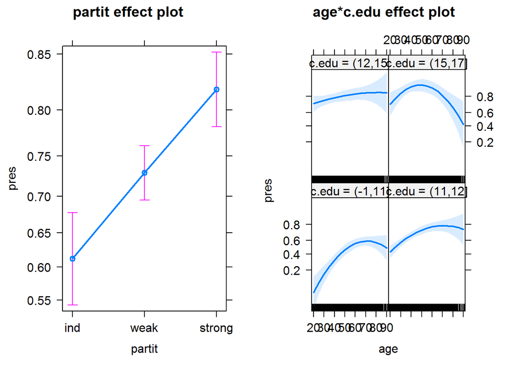

```r
plot(allEffects(m6.2),ask=FALSE)
```

```r
m6 <- m6.2
```

10. Introduïu la variable ‘grau d’interès’ en les eleccions en el model. Contrasteu la significació del seu efecte principal emprant: test de Wald (si es paquet estadístic us ho permet) i el test de la deviança. Afirmaríeu que la principal raó per la que la gent jove vota menys és que no estan interessats en les eleccions?
11. Introduïu en el model un terme d’interacció entre el ‘grau d’interès’ i les ‘preferències partidistes’. Contrasteu la significació de la interacció mitjançant el test de deviança. Expliqueu detalladament, si hi ho trobeu evidència, com funciona la interacció.
12. Hi ha alguna evidència que, després d’introduir el factor de ‘proximitat entre els candidats’ en el model TREBALLAT FINS EL MOMENT (EDAT, EDUCACIO, PREFERÈNCIES PARTIDISTES, GRAU D’INTERÈS), les persones que creuen que les eleccions són ajustades tinguin una major incidència de vot?
13. Considereu la satisfacció amb les candidatures. La gent que no està satisfeta amb les candidatures té una menor incidència de vot? Canviaria la conclusió si el ‘grau d’interès’ en les eleccions no estigués inclòs en el model?
14. Feu la diagnosi del vostre model final.
15. Empreu el vostre model final per predir el comportament d’un votant. Classifiqueu com a votant probable aquells individus amb probabilitat superior o igual a 0.5. Feu una taula de contingència amb el vot probable i el vot real i analitzeu-la. Quina és l’explicabilitat del model final?
16. Calculeu el pseudo coeficient de determinació del model final i el coeficient de Naglekerke. Feu un goodness of fit test sobre el model final. Calculeu el goodness of fit emprant l’estadístic proposat per Hosmer-Lemershow.
17. Determineu la capacitat predictiva mitjançant l’anàlisi de la corba ROC.